# Starts and Stops in the HIV genome

We're going to try to do what the folks did for the first full sequence of the HIV genome: [check out the paper here](http://www.nature.com/nature/journal/v313/n6000/abs/313277a0.html)

```python
# you kids can ignore this housekeeping code for now
from datascience import *
%matplotlib inline
import matplotlib.pyplot as plots
import numpy as np
plots.style.use('fivethirtyeight')
```

## Import the reference genome

HXB2 is the name of the reference strain for HIV. A datascience table is not an appropriate object for storing a single DNA sequence, so after importing as a table, we'll do a hack to just get at the character string.

```python
hxb2_import=Table.read_table('https://raw.githubusercontent.com/shishiluo/Genomics-DataScience/master/data/hxb2.csv')
# hxb2_import is an empty table with the HIV genome as the second column heading
hxb2=hxb2_import.labels[1]
# the HIV sequence is stored in the label of column indexed by 1
# 'hxb2' is the official name for the reference HIV genome, so we'll use that name here too
```

```python
len(hxb2)
```

```
9719
```

```python
hxb2[:100] # the first 100 characters of the HIV genome
# only print the full hxb2 if you're curious what 9719 characters looks like
```

```
'tggaagggctaattcactcccaacgaagacaagatatccttgatctgtggatctaccacacacaaggctacttccctgattagcagaactacacaccagg'
```

## String comparisons

We want to find the start and stop codons in the HIV genome. To do this, we need to know how to compare strings.

```python
hxb2[:3] # returns the first three bases of hxb2
```

```
'tgg'
```

```python
# what do you think the following means?
hxb2[:3]=='tga'
```

```
False
```

**Q1**: What is the difference between `==` and `=`?

```python
# what about the following?
int(hxb2[:3]=='tga')
```

```
0
```

```python
# what about this?
hxb2[:3] in ['tga', 'gtg', 'aaa']
```

```
False
```

**Q2**: Check whether the first three bases of hxb2 make a start codon.

**Q3**: Do the same but for a stop codon.

## Making a string comparison into a function

**Q4**: To get some practice with creating functions, write a function that takes a 3-letter string and returns 1 if it is a start codon and 0 if it isn't. Here's a bit of code to get you started.

```python
def isStart(string):
    '''returns 1 if string (of length 3) is ATG (start codon)'''
    if len(string)!=3:
        return('String needs to be of length 3!')

    else:
        return('insert the critical piece of code here!')
```

```python
# test your function
isStart(hxb2[:3])
```

```
'insert the critical piece of code here!'
```

**Q5**: Create a similar function but for stop codons

**Q6**: Generalize your code so it can handle upper or lower case character strings

## Scanning the full genome

We are now ready to scan the entire HIV genome for start and stop codons. All that's needed is some arithmetic and a for loop.

DNA is translated in triplets (called codons). For the *reading frame* beginning at the first base, `hxb2[:3]` returns the first codon, `hxb2[3:6]` the second codon, etc.

**Q7**: Write a for loop that, at each iteration, prints the next codon in the hxb2 sequence. You might want to test out your loop on just the first 9 characters (hxb2_test below) so the output is easy to check.

```python
hxb2_test=hxb2[:9]
hxb2_test
```

```
'tggaagggc'
```

**Q8**: Modify the for loop so that instead of printing each codon, 1 is printed if it is a stop codon, 0 otherwise

**Q9**: Modify the loop one more time so that at each iteration, the output (0 or 1) is recorded in a list. Hint: `stop_codons=[]` initiates an empty list (the square brackets) called `stop_codons`. `stop_codons.append(0)` adds a zero to the list.

**Q10**: Plot `stop_codons` so that the x axis is codon number and the y axis is a 1 if the codon is a stop codon, 0 if not. Here's some code to get you going.

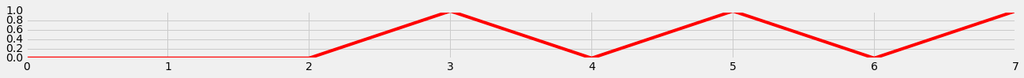

```python
fake_data=[0,0,0,1,0,1,0,1]
plots.figure(figsize=(20,1))
plots.plot(fake_data, 'r')
```

**Q11**: Now make a list of the start codons and plot them on a separate figure in green.

Every DNA sequence has three reading frames (positions from which codons can be read). So far, we have plotted the start and stop codons for the reading frame beginning with the first base. The reading frames beginning at the second and third base could also include stop and start codons.

**Q12**: Make a plot for the start codons and stop codons for each reading frame.

### For the perfectionists

Ideally, we'd like a vertical bar for each start and stop codon. In the plots above, the 'vertical' bars are actually really squished triangles (a line connecting 0, 1, and 0 very tightly).

Try typing `plots.axvline(x=5, linewidth=.5, color='r')` to see how one can plot vertical bars.

**Q13**: Make the same plots as before, but this time using plots.axvline() to get actual vertical bars. You will need to make a list of the positions of the start and stop codons.